# 301.1. DP2 overview

For the Rubin Science Platform at data.lsst.cloud.  
Data Release: [Data Preview 2](http://dp2.lsst.io)  
Container Size: Large  
LSST Science Pipelines version: r30.0.11  
Last verified to run: 2026-08-17  
Repository: github.com/lsst/tutorial-notebooks

**Learning objective:** Learn about the Data Preview 2 (DP2) dataset.

**LSST data products:** `Visit` and `CoaddPatches` tables, the `skymap`, and survey property maps

**Packages:** `lsst.daf.butler`, `lsst.rsp.RSPDiscovery`

**Credit:** Originally developed by the Rubin Community Science team. Please consider acknowledging them if this notebook is used for the preparation of journal articles, software releases, or other notebooks.

**Get Support:** Everyone is encouraged to ask questions or raise issues in the [Support Category](https://community.lsst.org/c/support) of the Rubin Community Forum. Rubin staff will respond to all questions posted there.

## 1. Introduction

This notebook provides an overview of the observations that were obtained during commissioning and science validation with the LSST Camera ([lsstcam.lsst.io](https://lsstcam.lsst.io/)), processed with v30 of the Rubin Science Pipelines ([pipelines.lsst.io](https://pipelines.lsst.io/)), and released as Data Preview 2 (DP2; [dp2.lsst.io](https://dp2.lsst.io/)).

The code in this notebook was used to generate the [DP2 observations overview webpage](https://dp2.lsst.io/).

**Key concepts for the DP2 dataset**

**Visit:** One visit is one observation (one image; one exposure) with the LSSTCam, centered on a sky coordinate and obtained with a single filter and sky rotation.

**Skymap, tract, and patch:** One tract is one square region of LSST's all-sky tesselation, the "skymap". Tracts are $~1.66$ deg per side, identified by a unique four-digit number, and are subdivided into 100 overlapping patches. One deep coadd image is created per patch in each band, provided sufficient input visits exist. The tract and patch numbers together with the filter uniquely identify a deep coadd image.

**For DP2, the area covered by visits is greater than the area covered by deep coadd images.** The sky area for which DP2 deep coadd images would be created was defined in late 2025 to include only the Wide-Fast-Deep, Small Field Survey, and Deep Drilling Field sky regions. See the [Science Validation Survey Overview - Summary 20250930](https://survey-strategy.lsst.io/progress/sv_status/sv_20250930.html) webpage for more information about these regions. Additional visits outside of the deep coadd regions are included in DP2 as processed visit images only. Sources in this additional sky area appear only in the `Source` table (detections in the individual visit images), and not in the `Object` table (detections in the deep coadd images).

**Related tutorials**: Refer to the 100-level tutorials for how to use the RSP's butler and TAP services, and the 200-level tutorials for details on the visit table, deep coadd images, and survey property maps.

### 1.1. Import packages

Import `numpy` (numpy.org) for data array manipulation, `matplotlib` ([matplotlib.org](https://matplotlib.org/)) for plotting. Import `astropy` ([astropy.org](https://www.astropy.org/)) and `skyproj` ([skyproj.readthedocs.io](https://skyproj.readthedocs.io/en/latest/)) for astronomy-specific functionality, and the `healpy` ([healpy.readthedocs.io](https://healpy.readthedocs.io/en/latest/)) and `hpgeom` ([hpgeom.readthedocs.io](https://hpgeom.readthedocs.io/en/latest/)) packages for dealing with HEALPix. Also import python's "garbage collector" `gc` in order to clear memory while running the notebook.

From the `lsst` package, import modules for data access: `RSPDiscovery` and the Butler. Use the plotting utilities in `lsst.utils.plotting` to access LSST-standard color schemes, symbols, and line styles for multi-band visualizations.

```python
import numpy as np
import matplotlib.pyplot as plt
import matplotlib.colors as mcolors
from astropy.coordinates import SkyCoord
from astropy.table import Table, join
from astropy.time import Time
import astropy.units as u
import skyproj
import healpy as hp
import hpgeom as hpg
import gc
from lsst.rsp import RSPDiscovery
from lsst.daf.butler import Butler
from lsst.utils.plotting import (
    get_multiband_plot_colors,
    get_multiband_plot_symbols,
    get_multiband_plot_linestyles
)
```

### 1.2. Define parameters and functions

Instantiate the Butler for the DP2 dataset.

```python
butler = Butler('dp2', collections='dp2')
```

Instantiate the TAP service.

```python
discovery = RSPDiscovery("dp2")
tap_service = discovery.get_tap_client()
```

Define colors, symbols, and linestyles to represent the six LSST filters, $ugrizy$.

```python
filter_colors = get_multiband_plot_colors()
filter_names = filter_colors.keys()
filter_symbols = get_multiband_plot_symbols()
filter_linestyles = get_multiband_plot_linestyles()
```

Uncomment and execute the following code cell to display plots interactively. Revert to non-interactive plots by executing `%matplotlib inline`, or by re-commenting the line, restarting the kernel and clearing all outputs, and re-executing the notebook.

```python
# %matplotlib widget
```

Define dictionaries with the Data Preview 2 names and centers for Deep Drilling Fields (DDFs) and small field surveys (SFS). The coordinates are Right Ascension and Declination as International Celestial Reference System (ICRS) coordinates in decimal degrees.

A radius in degrees is defined with the coordinates: it is *approximate*, and encompasses only the *boresight* (field-of-view center) coordinates for all individual visits of that field. It does not encompass every detector, or every skymap patch, or every detected source or object associated with that field.

```python
regions = {
    "DDF_ELAIS_S1": [9.5, -44.0, 1.0],
    "DDF_XMM_LSS": [35.6, -4.8, 1.0],
    "DDF_ECDFS": [53.0, -28.1, 1.0],
    "DDF_EDFS_a": [59.2, -49.2, 1.5],
    "DDF_EDFS_b": [63.2, -47.8, 1.5],
    "DDF_COSMOS": [150.1, 2.1, 1.0],
    "Abell_2764": [5.5, -49.0, 1.9],
    "DESI_SV3_R1": [180.5, -0.3, 0.8],
    "M49": [186.3, 6.9, 2.2],
    "Prawn": [253.5, -41.0, 2.7],
    "Trifid-Lagoon": [271.7, -23.9, 1.9],
    "New_Horizons": [289.4, -20.2, 1.5],
    "Rubin_SV_212_-7": [211.7, -7.0, 0.6],
    "Rubin_SV_216_-17": [216.1, -16.7, 0.4],
    "Rubin_SV_225_-40": [225.0, -39.5, 1.9],
    "Rubin_SV_280_-48": [280.1, -48.0, 2.0],
    "Rubin_SV_300_-41": [300.3, -41.0, 1.8],
    "Rubin_SV_320_-15": [320.2, -15.1, 4.51],
}
region_names = list(regions.keys())
```

Define a function that will remove a figure and all its data, to help clear memory.

```python
def remove_figure(fig):
    """
    Remove a figure to reduce memory footprint.

    Parameters
    ----------
    fig: matplotlib.figure.Figure
        Figure to be removed.

    Returns
    -------
    None
    """

    for ax in fig.get_axes():
        for im in ax.get_images():
            im.remove()
    fig.clf()
    plt.close(fig)
    gc.collect()
```

Define a function to truncate a colormap. This can be used to cut off, e.g., the darkest or lightest colors, to help with data visibility.

```python
def truncate_colormap(cmap, minval=0.0, maxval=1.0, n=256):
    """
    Customize a matplotlib colormap.

    Parameters
    ----------
    cmap: the matplotlib colormap
    minval: desired lower bound of colormap
    maxval: desired upper bound of colormap
    n: number of intervals (colormap resolution)

    Returns
    -------
    new_cmap: the truncated colormap
    """

    new_cmap = mcolors.LinearSegmentedColormap.from_list(
        'trunc({n},{a:.2f},{b:.2f})'.format(n=cmap.name, a=minval, b=maxval),
        cmap(np.linspace(minval, maxval, n)))
    return new_cmap
```

## 2. Visit metadata

Use the TAP service to return the visit id (`visit`), coordinates (`ra` and `dec`), filter (`band`), modified Julian date (MJD; `expMidptMJD`), and airmass of all visits included in DP2, from the `Visit` table.

```python
query = """SELECT visit, ra, dec, band, expMidptMJD, airmass FROM dp2.Visit"""
job = tap_service.submit_job(query)
job.run()
job.wait(phases=['COMPLETED', 'ERROR'])
print('Job phase is', job.phase)
if job.phase == 'ERROR':
    job.raise_if_error()
assert job.phase == 'COMPLETED'
visit_table = job.fetch_result().to_table()
job.delete()
del query
```

```
Job phase is COMPLETED
```

### 2.1. Sky map

Visualize the density of visits on an all-sky map.

Use the `healpy` package to print the area of one 19-sided HEALPix, to show that it is similar to the LSSTCam field of view (FOV) of 9.6 square degrees.

```python
print('One 19-sided HEALPix is ', np.round(hp.nside2pixarea(19, degrees=True), 2),
      ' square degrees.')
print('It takes ', int(41253.0 / hp.nside2pixarea(19, degrees=True)),
      ' 19-sided HEALPix to cover the full sky.')
```

```
One 19-sided HEALPix is  9.52  square degrees.
It takes  4332  19-sided HEALPix to cover the full sky.
```

Use the `skyproj` package with a McBryde sky projection to visualize the distribution of DP2 visits on the sky in HEALPix that are approximately the same size as the LSSTCam FOV (`nside`=19).

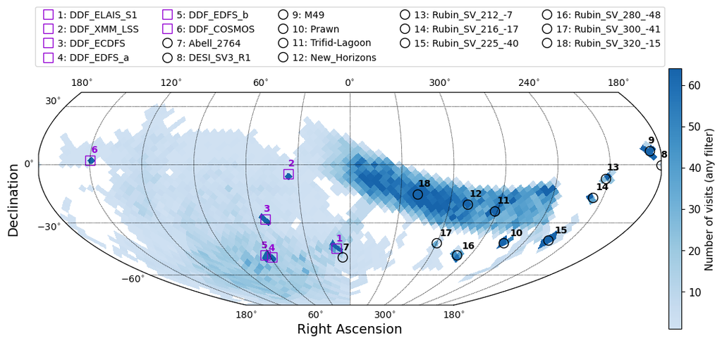

```python
orig_cmap = plt.get_cmap('Blues')
new_cmap = truncate_colormap(orig_cmap, 0.20, 0.8)

fig, ax = plt.subplots(figsize=(12, 8))
sp = skyproj.McBrydeSkyproj(ax=ax)
vras = visit_table['ra'].value.data
vdecs = visit_table['dec'].value.data
sp.draw_hpxbin(vras, vdecs, nside=19, alpha=1, cmap=new_cmap)
sp.draw_colorbar(label='Number of visits (any filter)', shrink=0.5, pad=0.01)
for r, name in enumerate(region_names):
    color = 'black'
    symbol = 'o'
    if name[0:3] == 'DDF':
        color = 'darkviolet'
        symbol = 's'
    sp.ax.text(regions[name][0], regions[name][1]+4, str(r+1), color=color, fontweight='bold')
    sp.ax.plot(regions[name][0], regions[name][1], symbol, ms=10, color='None', mec=color,
               label=str(r+1)+': '+name)
sp.ax.set_xlabel("Right Ascension", fontsize=14)
sp.ax.set_ylabel("Declination", fontsize=14)
sp.ax.legend(loc="lower center", bbox_to_anchor=(0.5, 1.1), ncol=5, handletextpad=0)
plt.tight_layout()
plt.show()
del sp
```

> **Figure 1:** A density map of the number of visits in blue, with Deep Drilling Fields marked with violet squares and small field survey areas marked with black circles. Field numbers are labeled in the legend above. Note that fields "Abell_2764" (7) and "DESI_SV3_R1" (8) have very few visits.

### 2.2. Filter distributions

Sum up the number of visits per filter.

Instantiate an `astropy` table to hold the values: `field_filt_dist`.

```python
columns = ['Field', 'u', 'g', 'r', 'i', 'z', 'y', 'Total']
fields = np.asarray(region_names + ['All'], dtype='str')
temp = np.zeros(len(fields), dtype='int')
field_filt_dist = Table([fields, temp, temp, temp, temp, temp, temp, temp], names=columns)
del columns, fields, temp
```

Tally the number of visits per field, per filter, and over all filters and all visits.

```python
sc_all = SkyCoord(ra = vras*u.deg, dec = vdecs*u.deg, frame='icrs')

for i, name in enumerate(region_names):
    ra, dec, rad = regions[name]
    sc_region = SkyCoord(ra = ra*u.deg, dec = dec*u.deg, frame='icrs')
    tx = np.where(sc_region.separation(sc_all).value <= rad)[0]
    for filt in filter_names:
        field_filt_dist[filt][i] = len(np.where(visit_table['band'][tx] == filt)[0])
    field_filt_dist['Total'][i] = len(tx)
    del ra, dec, rad, tx

i = np.where(field_filt_dist['Field'] == "All")[0]
for filt in filter_names:
    field_filt_dist[filt][i] = len(np.where(visit_table['band'] == filt)[0])
field_filt_dist['Total'][i] = len(visit_table)
```

Display the table.

```python
field_filt_dist
```

*Table length=19*

| Field str16 | u int64 | g int64 | r int64 | i int64 | z int64 | y int64 | Total int64 |
| --- | --- | --- | --- | --- | --- | --- | --- |
| DDF_ELAIS_S1 | 59 | 159 | 133 | 237 | 146 | 65 | 799 |
| DDF_XMM_LSS | 42 | 15 | 8 | 47 | 10 | 10 | 132 |
| DDF_ECDFS | 10 | 61 | 50 | 96 | 61 | 11 | 289 |
| DDF_EDFS_a | 7 | 31 | 33 | 59 | 34 | 9 | 173 |
| DDF_EDFS_b | 5 | 37 | 33 | 59 | 34 | 10 | 178 |
| DDF_COSMOS | 105 | 87 | 173 | 162 | 110 | 77 | 714 |
| Abell_2764 | 0 | 7 | 0 | 3 | 0 | 0 | 10 |
| DESI_SV3_R1 | 0 | 0 | 0 | 3 | 0 | 0 | 3 |
| M49 | 234 | 280 | 378 | 213 | 0 | 0 | 1105 |
| Prawn | 196 | 160 | 142 | 93 | 30 | 0 | 621 |
| Trifid-Lagoon | 240 | 210 | 134 | 124 | 10 | 8 | 726 |
| New_Horizons | 37 | 53 | 78 | 116 | 80 | 33 | 397 |
| Rubin_SV_212_-7 | 0 | 139 | 187 | 123 | 0 | 0 | 449 |
| Rubin_SV_216_-17 | 0 | 28 | 30 | 63 | 0 | 0 | 121 |
| Rubin_SV_225_-40 | 312 | 529 | 391 | 381 | 241 | 104 | 1958 |
| Rubin_SV_280_-48 | 30 | 30 | 29 | 31 | 29 | 0 | 149 |
| Rubin_SV_300_-41 | 0 | 8 | 0 | 0 | 30 | 0 | 38 |
| Rubin_SV_320_-15 | 12 | 49 | 106 | 267 | 216 | 82 | 732 |
| All | 1964 | 4166 | 4856 | 7959 | 5809 | 3944 | 28698 |

### 2.3. Epochs (nights)

Create a table with the number of visits per field, the number of unique nights (epochs) the field was observed, and the average number of visits per night.

```python
columns = ['Field', 'visits', 'nights', 'mean(visits/night)']
fields = np.asarray(region_names + ['All'], dtype='str')
temp = np.zeros(len(fields), dtype='int')
field_epochs = Table([fields, temp, temp, temp], names=columns)
del columns, fields, temp

for i, name in enumerate(region_names):
    ra, dec, rad = regions[name]
    sc_region = SkyCoord(ra = ra*u.deg, dec = dec*u.deg, frame='icrs')
    tx = np.where(sc_region.separation(sc_all).value <= rad)[0]
    field_epochs['visits'][i] = len(tx)
    unique_nights = np.unique(np.floor(visit_table['expMidptMJD'][tx]))
    field_epochs['nights'][i] = len(unique_nights)
    field_epochs['mean(visits/night)'][i] = int(np.round(len(tx)/len(unique_nights), 0))
    del ra, dec, rad, tx, unique_nights

i = np.where(field_epochs['Field'] == "All")[0]
field_epochs['visits'][i] = len(visit_table)
unique_nights = np.unique(np.floor(visit_table['expMidptMJD']))
field_epochs['nights'][i] = len(unique_nights)
field_epochs['mean(visits/night)'][i] = int(np.round(len(visit_table)/len(unique_nights), 0))
del i, unique_nights
```

```python
field_epochs
```

*Table length=19*

| Field str16 | visits int64 | nights int64 | mean(visits/night) int64 |
| --- | --- | --- | --- |
| DDF_ELAIS_S1 | 799 | 62 | 13 |
| DDF_XMM_LSS | 132 | 23 | 6 |
| DDF_ECDFS | 289 | 37 | 8 |
| DDF_EDFS_a | 173 | 51 | 3 |
| DDF_EDFS_b | 178 | 50 | 4 |
| DDF_COSMOS | 714 | 21 | 34 |
| Abell_2764 | 10 | 3 | 3 |
| DESI_SV3_R1 | 3 | 1 | 3 |
| M49 | 1105 | 7 | 158 |
| Prawn | 621 | 7 | 89 |
| Trifid-Lagoon | 726 | 24 | 30 |
| New_Horizons | 397 | 25 | 16 |
| Rubin_SV_212_-7 | 449 | 5 | 90 |
| Rubin_SV_216_-17 | 121 | 2 | 60 |
| Rubin_SV_225_-40 | 1958 | 29 | 68 |
| Rubin_SV_280_-48 | 149 | 2 | 74 |
| Rubin_SV_300_-41 | 38 | 2 | 19 |
| Rubin_SV_320_-15 | 732 | 34 | 22 |
| All | 28698 | 131 | 219 |

### 2.4. Accumulation over time

Plot the cumulative number of visits over time, for all regions and filters.

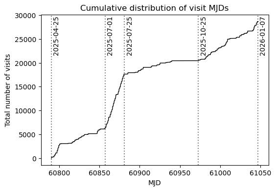

```python
notable_mjds = [np.floor(np.min(visit_table['expMidptMJD'])),
                60857, 60881, 60973,
                np.floor(np.max(visit_table['expMidptMJD']))]
fig = plt.figure(figsize=(6, 4))
for i, mjd in enumerate(notable_mjds):
    plt.axvline(mjd, ls='dotted', color='grey')
    t = Time(mjd, format='mjd', scale='utc')
    s = str(t.to_datetime())
    plt.text(mjd+2, 22000, s[0:10], rotation=90)
    del t, s
plt.plot(np.sort(visit_table['expMidptMJD']), np.arange(len(visit_table)),
         ls='solid', lw=1, color='black')
plt.xlabel('MJD')
plt.ylabel('Total number of visits')
plt.title('Cumulative distribution of visit MJDs')
plt.show()
del notable_mjds
```

> **Figure 2:** The cumulative distribution of visit MJDs (modified Julian dates) for all visits, for all filters combined. Notable dates are marked with vertical dotted lines: the start (Apr 25 2025) and end (Jan 07 2026) of the data collection window; a phase of rapid data acquisition (July 01-25 2025); and the end of the engineering shutdown when observations recommenced (Oct 25 2025).

### 2.5. Airmass distribution

Plot the cumulative distribution of airmass, for all regions and filters.

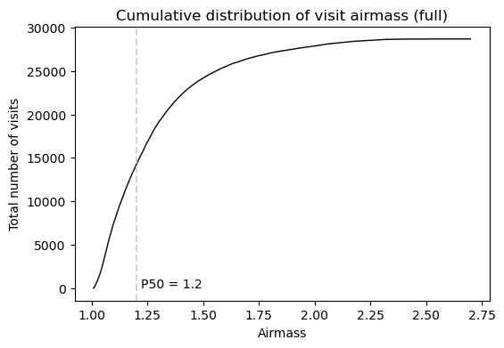

```python
fig = plt.figure(figsize=(6, 4))
xvals = np.sort(visit_table['airmass'])
yvals = np.arange(len(visit_table))
a_50 = xvals[np.where(yvals < len(visit_table)/2.0)[0][-1]]
plt.plot(xvals, yvals, ls='solid', lw=1, color='black')
plt.axvline(a_50, ls='dashed', color='lightgrey')
plt.text(a_50 + 0.02, 0, 'P50 = ' + str(np.round(a_50, 2)))
plt.xlabel('Airmass')
plt.ylabel('Total number of visits')
plt.title('Cumulative distribution of visit airmass (full)')
plt.show()
del xvals, yvals, a_50
```

> **Figure 3:** The cumulative distribution of visit airmass for all visits, for all filters combined. The 50th percentile for airmass is 1.2, and is marked with a dashed grey line.

### 2.6. Image quality

The `seeing` and magnitude limit `magLim` are estimated per-detector, and are available in the `VisitDetector` table.

Use the TAP service to return the seeing and magnitude limits, averaged over all detectors per visit, from the `VisitDetector` table.

```python
query = """SELECT visitId, AVG(seeing) AS mean_seeing, AVG(magLim) AS mean_maglim
           FROM dp2.VisitDetector GROUP BY visitId"""
job = tap_service.submit_job(query)
job.run()
job.wait(phases=['COMPLETED', 'ERROR'])
print('Job phase is', job.phase)
if job.phase == 'ERROR':
    job.raise_if_error()
assert job.phase == 'COMPLETED'
visit_detector_table = job.fetch_result().to_table()
job.delete()
del query
```

```
Job phase is COMPLETED
```

Combine the `mean_seeing` and `mean_maglim` columns with the `visit_table` using an `astropy` table join, to create the `joined_table`. To save memory, delete the original tables and run the garbage collector.

```python
joined_table = join(visit_table, visit_detector_table, keys_left="visit", keys_right="visitId")
del visit_table, visit_detector_table
gc.collect()
```

```
6290
```

Plot the distributions of seeing and magnitude limit.

Customize the line transparency and width for the image quality plots.

```python
filter_alphas = {'u': 1, 'g': 1, 'r': 0.8, 'i': 0.6, 'z': 1, 'y': 1}
filter_lw = {'u': 1.1, 'g': 1, 'r': 1, 'i': 0.8, 'z': 1, 'y': 1.1}
```

Create the seeing distribution plots.

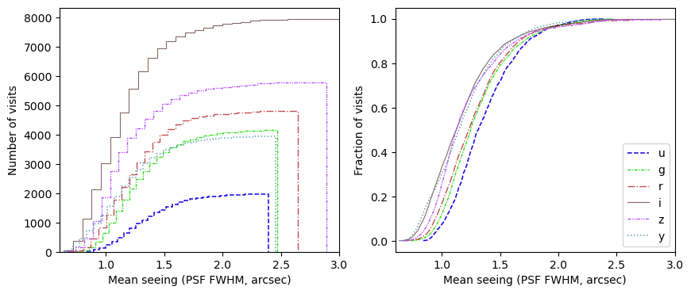

```python
fig, ax = plt.subplots(1, 2, figsize=(10, 4))
for filt in filter_names:
    fx = np.where(joined_table['band'] == filt)[0]
    xvals = np.sort(joined_table['mean_seeing'][fx])
    yvals = (np.arange(len(xvals), dtype='float') + 1) / len(xvals)
    ax[0].hist(joined_table['mean_seeing'][fx], 30, histtype='step', cumulative=True,
               alpha=filter_alphas[filt], lw=filter_lw[filt],
               ls=filter_linestyles[filt], color=filter_colors[filt], label=filt)
    ax[1].plot(xvals, yvals, ls=filter_linestyles[filt], lw=filter_lw[filt],
               alpha=filter_alphas[filt], color=filter_colors[filt], label=filt)
    del fx, xvals, yvals
ax[0].set_xlim([0.6, 3.0])
ax[1].set_xlim([0.6, 3.0])
ax[0].set_xlabel('Mean seeing (PSF FWHM, arcsec)')
ax[1].set_xlabel('Mean seeing (PSF FWHM, arcsec)')
ax[0].set_ylabel('Number of visits')
ax[1].set_ylabel('Fraction of visits')
ax[1].legend(loc='lower right')
plt.show()
```

> **Figure 4:** The cumulative number (left) and fraction (right) of visits as a function of mean seeing (PSF FWHM in arcseconds, averaged over all detectors), for a given filter. These plots include all regions.

Create the magnitude limits plots.

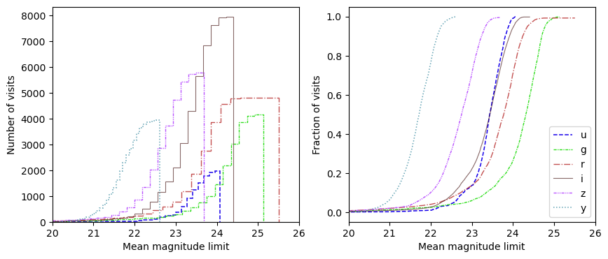

```python
fig, ax = plt.subplots(1, 2, figsize=(10, 4))
for filt in filter_names:
    fx = np.where(joined_table['band'] == filt)[0]
    xvals = np.sort(joined_table['mean_maglim'][fx])
    yvals = (np.arange(len(xvals), dtype='float') + 1) / len(xvals)
    ax[0].hist(joined_table['mean_maglim'][fx], 30, histtype='step', cumulative=True,
               alpha=filter_alphas[filt], lw=filter_lw[filt],
               ls=filter_linestyles[filt], color=filter_colors[filt], label=filt)
    ax[1].plot(xvals, yvals, ls=filter_linestyles[filt], lw=filter_lw[filt],
               alpha=filter_alphas[filt], color=filter_colors[filt], label=filt)
    del fx, xvals, yvals
ax[0].set_xlim([20, 26])
ax[1].set_xlim([20, 26])
ax[0].set_xlabel('Mean magnitude limit')
ax[1].set_xlabel('Mean magnitude limit')
ax[0].set_ylabel('Number of visits')
ax[1].set_ylabel('Fraction of visits')
ax[1].legend(loc='lower right')
plt.show()
```

> **Figure 5:** The cumulative number (left) and fraction (right) of visits as a function of mean magnitude limit (averaged over all detectors), for a given filter. These plots include all regions.

Create tables of the mean seeing and magnitude limit, averaged over all visits in a given filter, per region.

Because seeing and magnitude limit are filter-dependent, an average over all filters is not calculated.

```python
columns = ['Field', 'u', 'g', 'r', 'i', 'z', 'y']
fields = np.asarray(region_names + ['All'], dtype='str')
temp = np.zeros(len(fields), dtype='float')
field_seeing = Table([fields, temp, temp, temp, temp, temp, temp], names=columns)
field_maglim = Table([fields, temp, temp, temp, temp, temp, temp], names=columns)
del columns, fields, temp

for i, name in enumerate(region_names):
    ra, dec, rad = regions[name]
    sc_region = SkyCoord(ra = ra*u.deg, dec = dec*u.deg, frame='icrs')
    tx = np.where(sc_region.separation(sc_all).value <= rad)[0]
    for filt in filter_names:
        fx = np.where(joined_table['band'][tx] == filt)[0]
        if len(fx) > 0:
            field_seeing[filt][i] = np.round(np.mean(joined_table['mean_seeing'][tx[fx]]), 2)
            field_maglim[filt][i] = np.round(np.mean(joined_table['mean_maglim'][tx[fx]]), 2)
        else:
            field_seeing[filt][i] = np.nan
            field_maglim[filt][i] = np.nan
        del fx
    del ra, dec, rad, tx

i = np.where(field_seeing['Field'] == "All")[0]
for filt in filter_names:
    fx = np.where(joined_table['band'] == filt)[0]
    field_seeing[filt][i] = np.round(np.mean(joined_table['mean_seeing'][fx]), 2)
    field_maglim[filt][i] = np.round(np.mean(joined_table['mean_maglim'][fx]), 2)
    del fx
```

```python
field_seeing
```

*Table length=19*

| Field str16 | u float64 | g float64 | r float64 | i float64 | z float64 | y float64 |
| --- | --- | --- | --- | --- | --- | --- |
| DDF_ELAIS_S1 | 1.63 | 1.5 | 1.5 | 1.33 | 1.46 | 1.33 |
| DDF_XMM_LSS | 1.52 | 1.24 | 1.08 | 1.01 | 0.99 | 0.94 |
| DDF_ECDFS | 1.68 | 1.59 | 1.35 | 1.15 | 1.34 | 1.32 |
| DDF_EDFS_a | 1.56 | 1.39 | 1.39 | 1.12 | 1.29 | 0.98 |
| DDF_EDFS_b | 1.34 | 1.41 | 1.39 | 1.16 | 1.29 | 1.01 |
| DDF_COSMOS | 1.36 | 1.16 | 1.25 | 1.14 | 1.17 | 1.22 |
| Abell_2764 | nan | 1.0 | nan | 1.04 | nan | nan |
| DESI_SV3_R1 | nan | nan | nan | 1.47 | nan | nan |
| M49 | 1.49 | 1.37 | 1.27 | 1.22 | nan | nan |
| Prawn | 1.49 | 1.38 | 1.28 | 1.24 | 1.42 | nan |
| Trifid-Lagoon | 1.22 | 1.14 | 1.14 | 1.03 | 1.09 | 1.41 |
| New_Horizons | 1.26 | 1.36 | 1.12 | 1.04 | 1.01 | 1.12 |
| Rubin_SV_212_-7 | nan | 1.42 | 1.3 | 1.12 | nan | nan |
| Rubin_SV_216_-17 | nan | 1.35 | 1.25 | 1.31 | nan | nan |
| Rubin_SV_225_-40 | 1.51 | 1.43 | 1.27 | 1.24 | 1.32 | 1.25 |
| Rubin_SV_280_-48 | 1.69 | 1.53 | 1.52 | 1.35 | 1.53 | nan |
| Rubin_SV_300_-41 | nan | 1.86 | nan | nan | 1.65 | nan |
| Rubin_SV_320_-15 | 1.26 | 1.67 | 1.47 | 1.38 | 1.39 | 1.16 |
| All | 1.36 | 1.3 | 1.27 | 1.18 | 1.21 | 1.19 |

```python
field_maglim
```

*Table length=19*

| Field str16 | u float64 | g float64 | r float64 | i float64 | z float64 | y float64 |
| --- | --- | --- | --- | --- | --- | --- |
| DDF_ELAIS_S1 | 23.19 | 23.64 | 23.28 | 23.19 | 22.47 | 21.49 |
| DDF_XMM_LSS | 23.21 | 23.7 | 23.93 | 23.62 | 23.03 | 21.92 |
| DDF_ECDFS | 23.01 | 23.52 | 23.17 | 23.42 | 22.57 | 21.68 |
| DDF_EDFS_a | 23.1 | 23.62 | 23.23 | 23.47 | 22.52 | 21.94 |
| DDF_EDFS_b | 23.26 | 23.68 | 23.25 | 23.42 | 22.5 | 21.9 |
| DDF_COSMOS | 23.39 | 24.39 | 23.54 | 22.98 | 22.58 | 21.57 |
| Abell_2764 | nan | 24.87 | nan | 23.14 | nan | nan |
| DESI_SV3_R1 | nan | nan | nan | 23.5 | nan | nan |
| M49 | 23.29 | 24.3 | 23.85 | 23.44 | nan | nan |
| Prawn | 23.11 | 24.07 | 23.74 | 23.39 | 22.71 | nan |
| Trifid-Lagoon | 23.41 | 24.29 | 23.86 | 23.65 | 22.65 | 21.28 |
| New_Horizons | 23.17 | 24.41 | 24.11 | 23.63 | 22.94 | 21.88 |
| Rubin_SV_212_-7 | nan | 24.23 | 23.83 | 23.71 | nan | nan |
| Rubin_SV_216_-17 | nan | 24.34 | 24.02 | 23.62 | nan | nan |
| Rubin_SV_225_-40 | 23.29 | 23.97 | 23.52 | 23.33 | 22.75 | 21.63 |
| Rubin_SV_280_-48 | 22.59 | 23.45 | 23.27 | 23.15 | 22.27 | nan |
| Rubin_SV_300_-41 | nan | 23.25 | nan | nan | 22.31 | nan |
| Rubin_SV_320_-15 | 23.55 | 24.09 | 23.3 | 23.04 | 22.39 | 21.65 |
| All | 23.37 | 24.12 | 23.58 | 23.32 | 22.65 | 21.68 |

## 3. Deep coadd metadata

Metadata for the deep coadd images comes from the `skymap` and the survey property maps.

### 3.1. Skymap (tracts and patches)

The `skymap` of DP2 tracts and patches was defined before all the observations were obtained.

**Just because a tract and patch exists does not mean it is populated with a deep coadd image.** This will be demonstrated in Section 3.2.

Retrieve the DP2 patch and tract numbers (`lsst_patch`, `lsst_tract`), the center coordinates RA, Dec (`s_ra`, `s_dec`), and the polygon region defining the patch (`s_region`) from the `CoaddPatches` table.

```python
query = """SELECT lsst_patch, lsst_tract, s_dec, s_ra, s_region FROM dp2.CoaddPatches"""
job = tap_service.submit_job(query)
job.run()
job.wait(phases=['COMPLETED', 'ERROR'])
print('Job phase is', job.phase)
if job.phase == 'ERROR':
    job.raise_if_error()
assert job.phase == 'COMPLETED'
patches_table = job.fetch_result().to_table()
job.delete()
del query
```

```
Job phase is COMPLETED
```

Option to display the table.

```python
# patches_table
```

Get the unique tract numbers for DP2, and print their total number.

```python
tracts = np.unique(patches_table['lsst_tract'])
print('Number of tracts: ', len(tracts))
```

```
Number of tracts:  2191
```

Retrieve the DP2 `skymap`, named `lsst_cells_v2`, from the Butler.

```python
skymap = butler.get("skyMap", skymap="lsst_cells_v2")
```

#### 3.1.1. All-sky map of tracts

Draw one box per tract on an all-sky map using the same projection as in Figure 1.

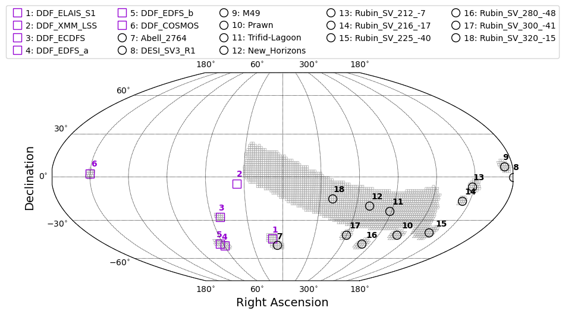

```python
fig, ax = plt.subplots(figsize=(10, 6))
sp = skyproj.McBrydeSkyproj(ax=ax)
for tract in tracts:
    info = skymap.generateTract(tract)
    vertex_list = info.getVertexList()
    ras = []
    decs = []
    for vertex in vertex_list:
        ras.append(vertex.getRa().asDegrees())
        decs.append(vertex.getDec().asDegrees())
    sp.draw_polygon(ras, decs, edgecolor='darkgrey', alpha=1, linewidth=0.5, facecolor=None)
    del info, vertex_list, ras, decs
for r, name in enumerate(region_names):
    color = 'black'
    symbol = 'o'
    if name[0:3] == 'DDF':
        color = 'darkviolet'
        symbol = 's'
    sp.ax.text(regions[name][0], regions[name][1]+5, str(r+1), color=color, fontweight="bold")
    sp.ax.plot(regions[name][0], regions[name][1], symbol, ms=10, color='None', mec=color,
               label=str(r+1)+': '+name)
sp.ax.set_xlabel("Right Ascension", fontsize=14)
sp.ax.set_ylabel("Declination", fontsize=14)
sp.ax.legend(loc="lower center", bbox_to_anchor=(0.5, 1.05), ncol=5, handletextpad=0)
plt.show()
del sp
```

> **Figure 6:** All pre-defined DP2 tracts. Note that fields DDF XMM LSS (2) and DESI SV3 R1 (8) do not overlap with any tracts and will not have any deep coadd images.

#### 3.1.2. Single-field map of patches

Draw one box per patch for the DDF ECDFS field (numbered 3 in Figure 6).

Recall from Section 1.2. that the third component of `regions[<name>]` is the radius within which the boresight center coordinates for all visits of the field are included. To capture all tracts that contain patches for which these visits might have contributed to a deep coadd image, add to that radius the tract's diagonal size $\sqrt{2\times1.66^2}$ degrees.

To better visualize tract and patch overlap, define a color dictionary for the three central tracts using the first colors from the `seaborn-v0_8-notebook` color map ([reference](https://matplotlib.org/stable/gallery/style_sheets/style_sheets_reference.html)).

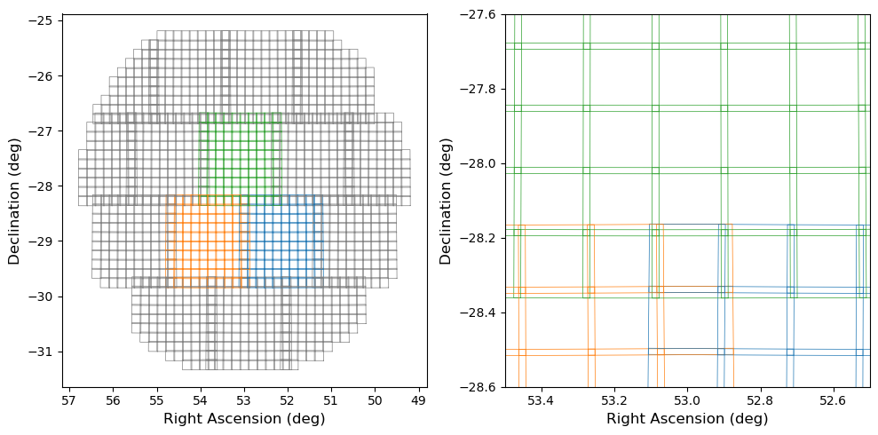

```python
name = "DDF_ECDFS"
ra, dec, rad = regions[name]
radius = rad + np.sqrt(2*1.66**2)
sc_patches = SkyCoord(ra = patches_table['s_ra'], dec = patches_table['s_dec'], frame='icrs')
sc_region = SkyCoord(ra = ra*u.deg, dec = dec*u.deg, frame='icrs')
tx = np.where(sc_region.separation(sc_patches).value <= radius)[0]
tract_color_dict = {4848: '#1f77b4', 4849: '#ff7f0e', 5063: '#2ca02c'}

fig, ax = plt.subplots(1, 2, figsize=(10, 5))
for x in tx:
    s_region = patches_table['s_region'][x]
    temp = s_region.split(' ')
    ras = np.asarray([temp[2], temp[4], temp[6], temp[8], temp[2]], dtype='float')
    decs = np.asarray([temp[3], temp[5], temp[7], temp[9], temp[3]], dtype='float')
    for a in [0, 1]:
        color = 'grey'
        if patches_table['lsst_tract'][x] in tract_color_dict:
            color = tract_color_dict[patches_table['lsst_tract'][x]]
        ax[a].plot(ras, decs, color=color, linewidth=0.5, alpha=1)
        ax[a].set_xlabel("Right Ascension (deg)", fontsize=12)
        ax[a].set_ylabel("Declination (deg)", fontsize=12)
    del s_region, temp, ras, decs
ax[1].set_xlim([ra-0.5, ra+0.5])
ax[1].set_ylim([dec-0.5, dec+0.5])
ax[0].invert_xaxis()
ax[1].invert_xaxis()
plt.tight_layout()
plt.show()
del name, ra, dec, rad, radius, tx, sc_patches, sc_region
```

> **Figure 7:** At left, all pre-defined patches for the EDCFS. At right, the zoom-in better shows that both tracts and individual patches within a tract overlap at their edges. The center three tracts are assigned colors to help with visualizing the overlap.

Option to print the unique tract numbers for a given field.

```python
# name = "DDF_ECDFS"
# ra, dec, rad = regions[name]
# radius = rad + np.sqrt(2*1.66**2)
# sc_patches = SkyCoord(ra = patches_table['s_ra'], dec = patches_table['s_dec'], frame='icrs')
# sc_region = SkyCoord(ra = ra*u.deg, dec = dec*u.deg, frame='icrs')
# tx = np.where(sc_region.separation(sc_patches).value <= rad)[0]
# tract_list = np.unique(patches_table['lsst_tract'][tx])
# print(name, tract_list)
# del name, ra, dec, rad, radius, tx, tract_list, sc_patches, sc_region
```

### 3.2. Image quality (survey property maps)

Use the survey property maps to explore the PSF (point-spread function) limiting magnitude and size (FWHM; full-width half-max) for the deep coadd images.

The two maps used in this demonstration are:

- PSF magnitude limit, or "depth": `deepCoadd_psf_maglim_consolidated_map_weighted_mean`
- PSF size (FWHM) in pixels (0.2"/pix): `deepCoadd_psf_size_consolidated_map_weighted_mean`

Maps are available per filter.

#### 3.2.1. All-sky map of depth (i-band)

Load the all-sky PSF magnitude limit map for the i-band. Degrade the resolution of the data returned, from `nside_sparse` = 32768 (the default) to 1024, so as to take up less space in memory.

```python
map_name = "deepCoadd_psf_maglim_consolidated_map_weighted_mean"
map_band = "i"
hspmap = butler.get(map_name, band=map_band, skymap="lsst_cells_v2",
                    parameters={'degrade_nside': 1024})
```

Print the resolution of the coverage map (always low-resolution) and of the retrieved survey property map (will match the `degrade_nside` parameter passed in the code cell above).

```python
default_nside_coverage = hspmap.nside_coverage
print('Coverage map resolution: ', hspmap.nside_coverage)
print('Retrieved data resolution:', hspmap.nside_sparse)
```

```
Coverage map resolution:  32
Retrieved data resolution: 1024
```

Visualize the all-sky PSF magnitude limit map.

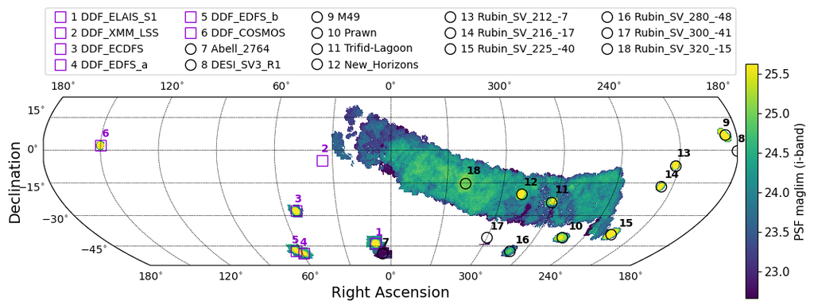

```python
fig, ax = plt.subplots(figsize=(14, 8))
sp = skyproj.McBrydeSkyproj(ax=ax, lon_0=0.0)
sp.draw_hspmap(hspmap)
for r, name in enumerate(region_names):
    color = 'black'
    symbol = 'o'
    if name[0:3] == 'DDF':
        color = 'darkviolet'
        symbol = 's'
    sp.ax.text(regions[name][0], regions[name][1]+4, str(r+1), color=color, fontweight="bold")
    sp.ax.plot(regions[name][0], regions[name][1], symbol, ms=10, color='None', mec=color,
               label=str(r+1)+' '+name)
temp = map_name.split("_")
label = "PSF " + temp[2] + " (" + map_band + "-band)"
sp.draw_colorbar(label=label, shrink=0.5, pad=0.01)
sp.ax.set_xlabel("Right Ascension", fontsize=14)
sp.ax.set_ylabel("Declination", fontsize=14)
sp.ax.legend(loc="lower center", bbox_to_anchor=(0.5, 1.1), ncol=5, handletextpad=0)
plt.show()
del sp, temp, label
```

> **Figure 8:** The all-sky map of the PSF magnitude limit in the i-band. Note that fields Abell 2764 (7) and Rubin SV 300 -41 (17), which do overlap with pre-defined tracts (Fig 6), have shallow and non-existent deep coadds, respectively.

Clear space in memory.

```python
remove_figure(fig)
del hspmap
gc.collect()
```

```
3236
```

#### 3.2.2. Single-field map of PSF size (g-band)

Instead of magnitude limit, load the PSF size map for the $g$-band, and only for HEALPix pixels that overlap DDF ECDFS.

> **Note:** the PSF size survey property map stores $\sigma$ in pixels, not FWHM in arcseconds. To convert, multiply by the pixel scale, 0.2 arcsec/pixel, and by 2.35 to convert from $\sigma$ to FWHM.

```python
map_name = "deepCoadd_psf_size_consolidated_map_weighted_mean"
map_band = "g"
name = "DDF_ECDFS"
coords = regions[name]
radius = coords[2] + np.sqrt(2*1.66**2)
sc_patches = SkyCoord(ra = patches_table['s_ra'], dec = patches_table['s_dec'], frame='icrs')
sc_region = SkyCoord(ra = coords[0]*u.deg, dec = coords[1]*u.deg, frame='icrs')
tx = np.where(sc_region.separation(sc_patches).value <= radius)[0]
pixels = np.unique(np.array(hpg.angle_to_pixel(default_nside_coverage,
                                               patches_table['s_ra'][tx],
                                               patches_table['s_dec'][tx])))
hspmap = butler.get(map_name, band=map_band, skymap='lsst_cells_v2',
                    parameters={'pixels': list(pixels), 'degrade_nside': 1024})
```

Visualize the PSF FWHM for the DDF ECDFS field.

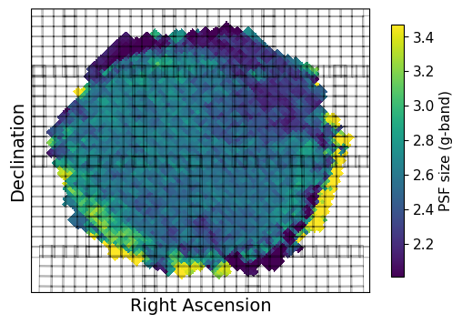

```python
fig, ax = plt.subplots(figsize=(6, 6))
sp = skyproj.Skyproj(ax=ax)
sp.draw_hspmap(hspmap)
temp = map_name.split("_")
label = "PSF " + temp[2] + " (" + map_band + "-band)"
sp.draw_colorbar(label=label, shrink=0.6, pad=0.05)
sp.ax.set_xlabel("Right Ascension", fontsize=14)
sp.ax.set_ylabel("Declination", fontsize=14)
sp.ax.grid(False)
del temp, label
for x in tx:
    s_region = patches_table['s_region'][x]
    temp = s_region.split(' ')
    ras = np.asarray([temp[2], temp[4], temp[6], temp[8], temp[2]], dtype='float')
    decs = np.asarray([temp[3], temp[5], temp[7], temp[9], temp[3]], dtype='float')
    sp.ax.plot(ras, decs, color='black', alpha=0.5, linewidth=0.5)
    del s_region, temp, ras, decs
plt.show()
del sp
```

> **Figure 9:** The map of the PSF size, $\sigma$, in pixels (0.2"/pix) for the $g$-band, for HEALPix of the survey property map that overlap the DDF ECDFS. Patch boxes are drawn in black. The FWHM in arcseconds is $\sigma$ $\times$0.2"/pixel $\times$2.35 ($=0.47\sigma$).

```python
remove_figure(fig)
del name, coords, radius, tx, pixels
del hspmap
gc.collect()
```

```
3155
```

#### 3.2.3. Image quality at field centers

Option to create tables of the image quality values, PSF magnitude limit and size, at the centers of the individual fields (`regions`).

These are commented-out and are optional because they take >10 minutes to execute. They are included because they were used to generated the [DP2 observations overview webpage](https://dp2.lsst.io/).

```python
# columns = ['Field', 'u', 'g', 'r', 'i', 'z', 'y']
# fields = np.asarray(region_names, dtype='str')
# temp = np.zeros(len(fields), dtype='float')
# field_coadd_maglim = Table([fields, temp, temp, temp, temp, temp, temp], names=columns)
# field_coadd_size = Table([fields, temp, temp, temp, temp, temp, temp], names=columns)
# del columns, fields, temp
```

```python
# map_name = "deepCoadd_psf_maglim_consolidated_map_weighted_mean"
# print("Reading psf maglim map for filter: ")
# for filt in filter_names:
#     print(filt)
#     hspmap = butler.get(map_name, band=filt, skymap='lsst_cells_v2',
#                         parameters={'degrade_nside': 512})
#     for i, name in enumerate(region_names):
#         ra, dec, rad = regions[name]
#         field_coadd_maglim[filt][i] = np.round(hspmap.get_values_pos(ra, dec), 2)
#         if field_coadd_maglim[filt][i] < 0:
#             field_coadd_maglim[filt][i] = np.nan
#         del ra, dec, rad
#     del hspmap
```

```python
# field_coadd_maglim
```

```python
# map_name = "deepCoadd_psf_size_consolidated_map_weighted_mean"
# print("Reading psf size map for filter: ")
# for filt in filter_names:
#     print(filt)
#     hspmap = butler.get(map_name, band=filt, skymap='lsst_cells_v2',
#                         parameters={'degrade_nside': 1024})
#     for i, name in enumerate(region_names):
#         ra, dec, rad = regions[name]
#         field_coadd_size[filt][i] = np.round(hspmap.get_values_pos(ra, dec), 2)
#         if field_coadd_size[filt][i] < 0:
#             field_coadd_size[filt][i] = np.nan
#         del ra, dec, rad
#     del hspmap
```

```python
# field_coadd_size
```